# Homework5

20210980108 颜帆

分析任务：

1. 读入数据并了解各个自变量的含义；
2. 对变量交易笔数 和 所有用户行为均值 分别绘制违约组和非违约组的对比箱线 图，并分析是否违约与这些变量之间的关系 ，给出解读
3. 按照 7:3划分训练集和测试集， 用决策树模型进行建模（提示： 划分数据集时 设定随机种子 =1234 在 R中可使用 rpart函数，设置为默认参数）；在测试集上 进行测试 绘制 ROC曲线，计算 AUC值。
4. 画出决策树的图形，并进行解读。

## 分析任务一

读入数据并了解各个自变量的含义。

```python
import numpy as np
import pandas as pd
import matplotlib.pyplot as plt
from sklearn import tree
import pydotplus
from sklearn.model_selection import train_test_split
from sklearn.metrics import classification_report,accuracy_score, auc, f1_score, precision_score, recall_score,roc_curve
from IPython.display import Image
from sklearn.tree import DecisionTreeClassifier
from sklearn.tree import plot_tree
```

```python
# 读入数据
data = pd.read_csv('simudata.csv',sep = ',')
data
```

|  | creded | debitF | meanpay | billnum | debitM | zhongxingM | sidaM | xindaiR | cardnum | xindaiF | ... | sidaR | zhongxingF | zhongxingR | xiaofeiF | jinkaF | zhuanzhangM | gongjiaoM | youxiM | xindaiS | black |
| --- | --- | --- | --- | --- | --- | --- | --- | --- | --- | --- | --- | --- | --- | --- | --- | --- | --- | --- | --- | --- | --- |
| 0 | 0.02 | 28 | 474795 | 4 | 784137.54 | 56826 | 307042 | 365.00 | 2 | 6 | ... | 7.83 | 4 | 334.38 | 6 | 9 | 508646.02 | 297.83 | 66.02 | 5760.22 | 1 |
| 1 | 0.16 | 2 | 346573 | 32 | 1217.43 | 43644 | 15096 | 311.73 | 9 | 0 | ... | 91.77 | 14 | 365.00 | 1 | 11 | 425876.24 | 3521.03 | 22.75 | 83872.62 | 1 |
| 2 | 0.32 | 56 | 168844 | 191 | 95001.76 | 279217 | 69815 | 42.32 | 8 | 0 | ... | 36.05 | 10 | 27.08 | 1 | 2 | 492287.84 | 467.64 | 6.66 | 31110.55 | 1 |
| 3 | 0.01 | 28 | 69002 | 89 | 487782.48 | 273731 | 329437 | 81.60 | 15 | 1 | ... | 10.08 | 8 | 191.04 | 1 | 8 | 240067.26 | 288.67 | 119.98 | 7876.13 | 1 |
| 4 | 0.19 | 6 | 408647 | 104 | 22039.56 | 13529 | 24725 | 254.60 | 17 | 9 | ... | 324.21 | 23 | 248.39 | 7 | 0 | 455464.47 | 11834.25 | 28.97 | 13765.38 | 0 |
| ... | ... | ... | ... | ... | ... | ... | ... | ... | ... | ... | ... | ... | ... | ... | ... | ... | ... | ... | ... | ... | ... |
| 8027 | 0.31 | 7 | 134240 | 103 | 45087.85 | 136167 | 350033 | 127.70 | 1 | 4 | ... | 215.10 | 34 | 82.39 | 6 | 1 | 812731.90 | 1058.44 | 647.91 | 123803.67 | 1 |
| 8028 | 0.17 | 0 | 322906 | 81 | 307575.51 | 390132 | 494558 | 64.52 | 3 | 1 | ... | 276.75 | 10 | 23.82 | 1 | 0 | 93830.00 | 1299.33 | 41.21 | 7532.98 | 0 |
| 8029 | 0.18 | 61 | 72099 | 57 | 492093.45 | 80562 | 705958 | 341.86 | 2 | 6 | ... | 32.11 | 1 | 365.00 | 0 | 6 | 83075.89 | 28291.09 | 3.94 | 63898.09 | 0 |
| 8030 | 0.07 | 13 | 152864 | 134 | 506255.19 | 85309 | 31359 | 158.15 | 10 | 10 | ... | 45.73 | 16 | 277.75 | 5 | 1 | 409679.28 | 1994.96 | 38.80 | 2994.33 | 0 |
| 8031 | 0.00 | 20 | 689482 | 13 | 56388.19 | 174007 | 164261 | 219.01 | 1 | 4 | ... | 235.46 | 2 | 365.00 | 1 | 11 | 106331.85 | 13569.00 | 161.12 | 166285.16 | 0 |

8032 rows × 27 columns

```python
#查看数据的列名
print(data.columns.values)
```

```
['creded' 'debitF' 'meanpay' 'billnum' 'debitM' 'zhongxingM' 'sidaM'
 'xindaiR' 'cardnum' 'xindaiF' 'maxpay' 'zhuanzhangF' 'gongjiaoF'
 'zhuanzhangR' 'age' 'gongjiaoR' 'sidaF' 'sidaR' 'zhongxingF' 'zhongxingR'
 'xiaofeiF' 'jinkaF' 'zhuanzhangM' 'gongjiaoM' 'youxiM' 'xindaiS' 'black']
```

```python
#查看数据相关信息概览
data.info()
```

```
<class 'pandas.core.frame.DataFrame'>
RangeIndex: 8032 entries, 0 to 8031
Data columns (total 27 columns):
 #   Column       Non-Null Count  Dtype
---  ------       --------------  -----
 0   creded       8032 non-null   float64
 1   debitF       8032 non-null   int64
 2   meanpay      8032 non-null   int64
 3   billnum      8032 non-null   int64
 4   debitM       8032 non-null   float64
 5   zhongxingM   8032 non-null   int64
 6   sidaM        8032 non-null   int64
 7   xindaiR      8032 non-null   float64
 8   cardnum      8032 non-null   int64
 9   xindaiF      8032 non-null   int64
```

[output cut: 19 more lines]

```python
# 查看自变量的统计信息
data.loc[:,data.columns != 'black'].describe()
```

|  | creded | debitF | meanpay | billnum | debitM | zhongxingM | sidaM | xindaiR | cardnum | xindaiF | ... | sidaF | sidaR | zhongxingF | zhongxingR | xiaofeiF | jinkaF | zhuanzhangM | gongjiaoM | youxiM | xindaiS |
| --- | --- | --- | --- | --- | --- | --- | --- | --- | --- | --- | --- | --- | --- | --- | --- | --- | --- | --- | --- | --- | --- |
| count | 8032.000000 | 8032.000000 | 8.032000e+03 | 8032.000000 | 8.032000e+03 | 8.032000e+03 | 8.032000e+03 | 8032.000000 | 8032.000000 | 8032.000000 | ... | 8032.000000 | 8032.000000 | 8032.000000 | 8032.000000 | 8032.000000 | 8032.000000 | 8.032000e+03 | 8032.000000 | 8032.000000 | 8032.000000 |
| mean | 0.144796 | 35.455802 | 2.717996e+05 | 74.471489 | 3.050731e+05 | 1.617706e+05 | 2.715348e+05 | 163.339720 | 6.394796 | 4.159985 | ... | 25.263446 | 148.532261 | 7.812251 | 237.543242 | 2.578312 | 6.101469 | 3.046979e+05 | 6079.254307 | 209.638073 | 106103.725818 |
| std | 0.143946 | 35.141984 | 2.352257e+05 | 71.310466 | 2.597760e+05 | 1.714516e+05 | 2.460283e+05 | 104.671216 | 4.379306 | 3.633870 | ... | 25.356962 | 99.256973 | 8.336176 | 106.227388 | 3.035972 | 7.047664 | 2.963735e+05 | 7530.265840 | 260.277361 | 94056.103030 |
| min | 0.000000 | 0.000000 | 0.000000e+00 | 0.000000 | 2.600000e+01 | 3.000000e+00 | 1.000000e+01 | 0.020000 | 0.000000 | 0.000000 | ... | 0.000000 | 0.160000 | 0.000000 | 0.170000 | 0.000000 | 0.000000 | 3.821000e+01 | 0.020000 | 0.000000 | 8.050000 |
| 25% | 0.020000 | 5.000000 | 5.047525e+04 | 11.000000 | 5.930946e+04 | 2.161650e+04 | 4.469200e+04 | 70.175000 | 3.000000 | 1.000000 | ... | 4.000000 | 57.222500 | 1.000000 | 157.150000 | 0.000000 | 1.000000 | 4.583786e+04 | 804.827500 | 28.047500 | 18240.015000 |
| 50% | 0.100000 | 25.000000 | 2.312770e+05 | 55.000000 | 2.648380e+05 | 9.791300e+04 | 2.197690e+05 | 155.520000 | 6.000000 | 4.000000 | ... | 17.000000 | 136.135000 | 5.000000 | 251.330000 | 1.000000 | 3.000000 | 2.145178e+05 | 2245.550000 | 75.050000 | 87971.440000 |
| 75% | 0.240000 | 57.000000 | 4.253420e+05 | 119.000000 | 4.796458e+05 | 2.610935e+05 | 4.338408e+05 | 241.020000 | 9.000000 | 7.000000 | ... | 42.000000 | 219.947500 | 13.000000 | 340.050000 | 4.000000 | 10.000000 | 4.963003e+05 | 9483.372500 | 329.990000 | 165942.247500 |
| max | 0.820000 | 202.000000 | 1.346594e+06 | 427.000000 | 1.436086e+06 | 1.017770e+06 | 1.299826e+06 | 365.000000 | 26.000000 | 20.000000 | ... | 144.000000 | 365.000000 | 53.000000 | 365.000000 | 19.000000 | 44.000000 | 1.650050e+06 | 55745.070000 | 1939.000000 | 485178.350000 |

8 rows × 26 columns

综上，我们可以发现数据一共有8032行，27列。其中，自变量有26列，分别为['creded' 'debitF' 'meanpay' 'billnum' 'debitM' 'zhongxingM' 'sidaM' 'xindaiR' 'cardnum' 'xindaiF' 'maxpay' 'zhuanzhangF' 'gongjiaoF' 'zhuanzhangR' 'age' 'gongjiaoR' 'sidaF' 'sidaR' 'zhongxingF' 'zhongxingR' 'xiaofeiF' 'jinkaF' 'zhuanzhangM' 'gongjiaoM' 'youxiM' 'xindaiS']，为float64或者int64 浮点或者整数类型的自变量，我们也通过data.loc[:,data.columns != 'black'].describe()得到了自变量的统计结果，包括最大最小值、均值、方差等等。因变量为['black']，为int类型，值为0或者1，分别代表未违约和违约。可以看到数据并无缺失值，现在对自变量的含义进行说明：

该数据simudata.csv为某公司用户在第三方交易平台的用户的日常刷卡行为数据，数据提供了一批用户行为记录。包括：年龄、银行卡数、借贷比率、交易笔数、所有行为均值、 所有行为最大值等。均为连续变量，取值范围在describe()中已给出。  
在营销领域，RFM模型是用来衡量客户的价值和客户的创利能力的重要工具和手段。这个模型通过一个客户的近期购买行为、购买的总体频率以及花了多少钱三项指标来描述该客户的综合价值，具体如下：  
1 R Recency，最近一次消费，指上一次购买的时间到现在的距离。理论上，上一次消费时间越近的用户应该是相对而言活跃的用户。  
2 F Frequency，消费频率，即用户在限定的期间内产生购买的总次数。产生购买越频繁的用户，忠诚度越高。  
3 M Monetary，某个用户所有消费金额的平均值。  
4 由于这三个指标并不能够衡量用户产生行为的波动性，所以我们增加一个指标 S Standard Deviation 来衡量用户行为的波动性。

用户行为的分类通过银行卡信息表，以及商户分类信息表，根据业务场景，我们提取了以下类别，每个类别都对应着以上我们已经定义好的 RFMS四个指 标。类别包括：  
（1）借记类：刻画用户使用储蓄卡的交易行为。不同的用户习惯不同，采用储蓄卡和信用卡的倾向也可能不同。  
（2）消费类：刻画用户的日常消费行为。日常消费行为的金额以及频次不同用户的还款能力可能不同。  
（3）信贷类：刻画用户之前的小额贷款类行为。用户之前如果有其他消费贷款类行为可能已经习惯进行消费贷款，从而可能具备更良好的信用状况。  
（4）转账类：刻画用户的转账 行为。经常通过熊小贷 APP转账的用户可能与不转账的用户行为不同。  
（5）话费类：刻画用户的话费充值交易行为。话费充值是否规律与充值金额多少都可能意味着用户群体不同。  
（6）公缴类：刻画用户交水，电，煤气费等交易行为。公缴费用的多少与是否规律也可能说明用户群体的不同。  
（7）游戏类：刻画用户购买游戏点卡的行为。经常玩游戏的用户群体可能与不玩游戏的人不同。  
（8 9）四大行卡类以及中型银行卡类：四大行包括中国银行，中国农业银行，中国工商银行，中国建设银行，中型银行包括招商银行，浦发银行，兴业银行，平安银行等。这 个指标的设定有以下两方面原因： a. 不同公司的工资卡不同，小型创业公司一般采用中型银行的银行卡； b. 四大行的信用卡发放较为保守，所 以能够申请到四大行信用卡的人可能和采用其他银行信用卡的用户群体不同。  
（10）白金及金卡类：通过卡标首可以对应到银行卡是属于哪家银行的哪种类型的卡，例如招商银行的金葵花卡。我们搜索整理了相应银行的金卡和白金卡卡种名称，并对应到每一个用户。我们初步认为，拥有白金卡和金卡的用户具备更高的还款能力，所以用户群体不同。

## 分析任务二

对变量交易笔数和所有用户行为均值分别绘制违约组和非违约组的对比箱线图并分析是否违约与这些变量之间的关系，给出解读。

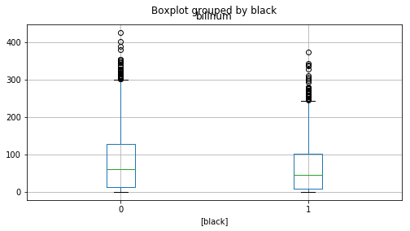

```python
# 交易笔数 的箱线图： 未违约 VS 违约
data.boxplot(column = ['billnum'],by=['black'],figsize=(8,4))
```

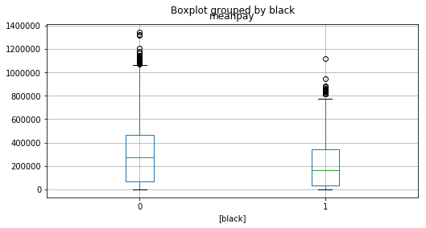

```python
# 所有用户行为均值 的箱线图： 未违约 VS 违约
data.boxplot(column = ['meanpay'],by=['black'],figsize=(8,4))
```

可以看到，对所有用户行为均值（用户被记录的所有交易形为的平均金额）而言，未违约用户的行为均值的中位数要明显高于违约用户，意味着未违约用户的消费的平均金额更高，与实际情况相符，因为违约用户通常意味着没钱还款导致违约，所以平时的消费能力肯定会更差。

## 分析任务三

按照 7:3划分训练集和测试集，用决策树模型进行建模（提示：划分数据集时，设定随机种子 =1234，在R中可使用rpart函数设置为默认参数）：在测试集上进行测试绘制ROC曲线，计算AUC值。

```python
X_train, X_test, y_train, y_test = train_test_split(data.loc[:,data.columns != 'black'], data.loc[:,data.columns == 'black'], test_size=0.3, random_state=1234)
X_train.shape
```

```
(5622, 26)
```

```python
X_test.shape
```

```
(2410, 26)
```

```python
print("训练集一共有样本数：",X_train.shape[0])
print("测试集一共有样本数：",X_test.shape[0])
```

```
训练集一共有样本数： 5622
测试集一共有样本数： 2410
```

```python
## 未剪枝
# CART 使用基尼指数来选择划分属性
model1 = DecisionTreeClassifier(random_state=0,criterion='gini')
model1.fit(X_train, y_train)
pred_model = model1.predict(X_train)
print('Train accuracy of the model is {:.4%}'.format(accuracy_score(y_train, pred_model)))
pred_model = model1.predict(X_test)
print('Test accuracy of the model is {:.4%}'.format(accuracy_score(y_test, pred_model)))
```

```
Train accuracy of the model is 100.0000%
Test accuracy of the model is 63.4025%
```

```python
## 未剪枝
#ID3决策树 使用信息增益来选择划分属性
model2 = DecisionTreeClassifier(random_state=0,criterion='entropy')
model2.fit(X_train, y_train)
pred_model = model2.predict(X_train)
print('Train accuracy of the model is {:.4%}'.format(accuracy_score(y_train, pred_model)))
pred_model = model2.predict(X_test)
print('Test accuracy of the model is {:.4%}'.format(accuracy_score(y_test, pred_model)))
```

```
Train accuracy of the model is 100.0000%
Test accuracy of the model is 65.5187%
```

使用ccp_alpha对决策树进行剪枝

```python
model3 = DecisionTreeClassifier(random_state=0,criterion='gini', ccp_alpha=0.006)
model3.fit(X_train, y_train)
pred_model = model3.predict(X_train)
print('Train accuracy of the model is {:.4%}'.format(accuracy_score(y_train, pred_model)))
pred_model = model3.predict(X_test)
print('Test accuracy of the model is {:.4%}'.format(accuracy_score(y_test, pred_model)))
```

```
Train accuracy of the model is 67.0580%
Test accuracy of the model is 65.6432%
```

```python
model4 = DecisionTreeClassifier(random_state=0,criterion='entropy', ccp_alpha=0.006)
model4.fit(X_train, y_train)
pred_model = model4.predict(X_train)

print('Train accuracy of the model is {:.4%}'.format(accuracy_score(y_train, pred_model)))

pred_model = model4.predict(X_test)
print('Test accuracy of the model is {:.4%}'.format(accuracy_score(y_test, pred_model)))
```

```
Train accuracy of the model is 69.6549%
Test accuracy of the model is 69.5436%
```

在测试集上画ROC曲线，计算AUC值。

```
Text(0,0.5,'true positive rate')
```

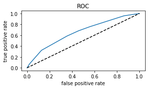

```python
y_score = model4.predict_proba(X_test)
fpr, tpr, thresholds = roc_curve(y_test, y_score[:, 1])  # ROC

# # 模型效果可视化
# names_list =(data.columns.difference(["black"])).tolist() # 分类模型维度列表
# color_list = ['r', 'c', 'b', 'g']  # 颜色列表
plt.figure(figsize=(10, 5))  # 创建画布
# 子网格1：ROC曲线
plt.subplot(2, 2, 1)  # 第一个子网格
plt.plot(fpr, tpr, label='ROC')  # 画出ROC曲线
plt.plot([0, 1], [0, 1], linestyle='--', color='k', label='random choice')  # 画出随机状态下的准确率线
plt.title('ROC')  # 子网格标题
plt.xlabel('false positive rate')  # X轴标题
plt.ylabel('true positive rate')  # y轴标题
```

```python
roc_auc = auc(fpr,tpr)
print("模型的AUC值为：",roc_auc)
```

```
模型的AUC值为： 0.6568759626395111
```

## 分析任务四

画出决策树的图形，并进行解读。

```python
feature_names = data.columns[:26]
target_names = data['black'].unique().tolist()
feature_names
```

```
Index(['creded', 'debitF', 'meanpay', 'billnum', 'debitM', 'zhongxingM',
       'sidaM', 'xindaiR', 'cardnum', 'xindaiF', 'maxpay', 'zhuanzhangF',
       'gongjiaoF', 'zhuanzhangR', 'age', 'gongjiaoR', 'sidaF', 'sidaR',
       'zhongxingF', 'zhongxingR', 'xiaofeiF', 'jinkaF', 'zhuanzhangM',
       'gongjiaoM', 'youxiM', 'xindaiS'],
      dtype='object')
```

```python
dot_data = tree.export_graphviz(model4, out_file=None, feature_names=feature_names, class_names=['0','1'],
                                filled=True, rounded=True, special_characters=True)
graph = pydotplus.graph_from_dot_data(dot_data)
graph.write_png('DesicionTree.png')
```

```
True
```

```python
graph
```

```
<pydotplus.graphviz.Dot at 0x7f531ccd4198>
```

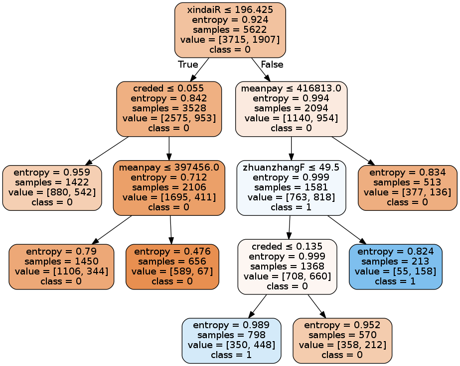

```python
Image("DesicionTree.png",width=700,height=800)
```

总的来说，决策树的根节点和内部节点的一个框内有五个表达式， 第一个为判别条件，第二个为选择改属性为判别条件的entropy，第三个值为改节点处有的样本的数量，第四个为这些样本数量中，取值为不同class的样本数，第五个为属于这个节点的样本的类别。 而我们是根据最后一次分枝情况来判别的样本数量，也就是决策树的叶节点，只包含四个表达式，没有第一个判别条件，因为此时已经不需要分枝了。